# Converting to and from Document-Term Matrix and Corpus objects

Julia Silge and David Robinson

2021-09-30

### Tidying document-term matrices

Many existing text mining datasets are in the form of a `DocumentTermMatrix` class (from the tm package). For example, consider the corpus of 2246 Associated Press articles from the topicmodels package:

```r
library(tm)
data("AssociatedPress", package = "topicmodels")
AssociatedPress
```

```
## <<DocumentTermMatrix (documents: 2246, terms: 10473)>>
## Non-/sparse entries: 302031/23220327
## Sparsity           : 99%
## Maximal term length: 18
## Weighting          : term frequency (tf)
```

If we want to analyze this with tidy tools, we need to turn it into a one-term-per-document-per-row data frame first. The `tidy` function does this. (For more on the tidy verb, [see the broom package](https://github.com/dgrtwo/broom)).

```r
library(dplyr)
library(tidytext)

ap_td <- tidy(AssociatedPress)
```

Just as shown in this vignette, having the text in this format is convenient for analysis with the tidytext package. For example, you can perform sentiment analysis on these newspaper articles.

```r
ap_sentiments <- ap_td %>%
  inner_join(get_sentiments("bing"), by = c(term = "word"))

ap_sentiments
```

```
## # A tibble: 30,094 × 4
##    document term    count sentiment
##       <int> <chr>   <dbl> <chr>
##  1        1 assault     1 negative
##  2        1 complex     1 negative
##  3        1 death       1 negative
##  4        1 died        1 negative
##  5        1 good        2 positive
##  6        1 illness     1 negative
##  7        1 killed      2 negative
##  8        1 like        2 positive
##  9        1 liked       1 positive
## 10        1 miracle     1 positive
## # … with 30,084 more rows
```

We can find the most negative documents:

```r
library(tidyr)

ap_sentiments %>%
  count(document, sentiment, wt = count) %>%
  spread(sentiment, n, fill = 0) %>%
  mutate(sentiment = positive - negative) %>%
  arrange(sentiment)
```

```
## # A tibble: 2,190 × 4
##    document negative positive sentiment
##       <int>    <dbl>    <dbl>     <dbl>
##  1     1251       54        6       -48
##  2     1380       53        5       -48
##  3      531       51        9       -42
##  4       43       45       11       -34
##  5     1263       44       10       -34
##  6     2178       40        6       -34
##  7      334       45       12       -33
##  8     1664       38        5       -33
##  9     2147       47       14       -33
## 10      516       38        6       -32
## # … with 2,180 more rows
```

Or visualize which words contributed to positive and negative sentiment:

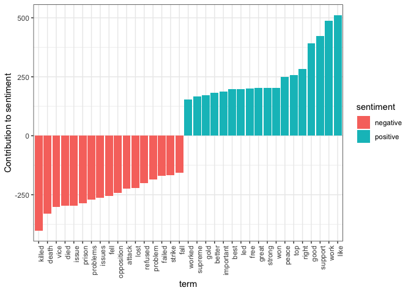

```r
library(ggplot2)

ap_sentiments %>%
  count(sentiment, term, wt = count) %>%
  filter(n >= 150) %>%
  mutate(n = ifelse(sentiment == "negative", -n, n)) %>%
  mutate(term = reorder(term, n)) %>%
  ggplot(aes(term, n, fill = sentiment)) +
  geom_bar(stat = "identity") +
  theme(axis.text.x = element_text(angle = 90, hjust = 1)) +
  ylab("Contribution to sentiment")
```

Note that a tidier is also available for the `dfm` class from the quanteda package:

```r
library(methods)

data("data_corpus_inaugural", package = "quanteda")
d <- quanteda::dfm(data_corpus_inaugural, verbose = FALSE)

d
```

```
## Document-feature matrix of: 59 documents, 9,439 features (91.84% sparse) and 4 docvars.
##                  features
## docs              fellow-citizens  of the senate and house representatives :
##   1789-Washington               1  71 116      1  48     2               2 1
##   1793-Washington               0  11  13      0   2     0               0 1
##   1797-Adams                    3 140 163      1 130     0               2 0
##   1801-Jefferson                2 104 130      0  81     0               0 1
##   1805-Jefferson                0 101 143      0  93     0               0 0
##   1809-Madison                  1  69 104      0  43     0               0 0
##                  features
## docs              among vicissitudes
##   1789-Washington     1            1
##   1793-Washington     0            0
##   1797-Adams          4            0
##   1801-Jefferson      1            0
##   1805-Jefferson      7            0
##   1809-Madison        0            0
## [ reached max_ndoc ... 53 more documents, reached max_nfeat ... 9,429 more features ]
```

```r
tidy(d)
```

```
## # A tibble: 45,453 × 3
##    document        term            count
##    <chr>           <chr>           <dbl>
##  1 1789-Washington fellow-citizens     1
##  2 1797-Adams      fellow-citizens     3
##  3 1801-Jefferson  fellow-citizens     2
##  4 1809-Madison    fellow-citizens     1
##  5 1813-Madison    fellow-citizens     1
##  6 1817-Monroe     fellow-citizens     5
##  7 1821-Monroe     fellow-citizens     1
##  8 1841-Harrison   fellow-citizens    11
##  9 1845-Polk       fellow-citizens     1
## 10 1849-Taylor     fellow-citizens     1
## # … with 45,443 more rows
```

### Casting tidy text data into a DocumentTermMatrix

Some existing text mining tools or algorithms work only on sparse document-term matrices. Therefore, tidytext provides `cast_` verbs for converting from a tidy form to these matrices.

```r
ap_td
```

```
## # A tibble: 302,031 × 3
##    document term       count
##       <int> <chr>      <dbl>
##  1        1 adding         1
##  2        1 adult          2
##  3        1 ago            1
##  4        1 alcohol        1
##  5        1 allegedly      1
##  6        1 allen          1
##  7        1 apparently     2
##  8        1 appeared       1
##  9        1 arrested       1
## 10        1 assault        1
## # … with 302,021 more rows
```

```r
# cast into a Document-Term Matrix
ap_td %>%
  cast_dtm(document, term, count)
```

```
## <<DocumentTermMatrix (documents: 2246, terms: 10473)>>
## Non-/sparse entries: 302031/23220327
## Sparsity           : 99%
## Maximal term length: 18
## Weighting          : term frequency (tf)
```

```r
# cast into a Term-Document Matrix
ap_td %>%
  cast_tdm(term, document, count)
```

```
## <<TermDocumentMatrix (terms: 10473, documents: 2246)>>
## Non-/sparse entries: 302031/23220327
## Sparsity           : 99%
## Maximal term length: 18
## Weighting          : term frequency (tf)
```

```r
# cast into quanteda's dfm
ap_td %>%
  cast_dfm(term, document, count)
```

```
## Document-feature matrix of: 10,473 documents, 2,246 features (98.72% sparse) and 0 docvars.
##            features
## docs        1 2 3 4 5 6 7 8 9 10
##   adding    1 0 0 0 0 0 0 0 0  0
##   adult     2 0 0 0 0 0 0 0 0  0
##   ago       1 0 1 3 0 2 0 0 0  0
##   alcohol   1 0 0 0 0 0 0 0 0  0
##   allegedly 1 0 0 0 0 0 0 0 0  0
##   allen     1 0 0 0 0 0 0 0 0  0
## [ reached max_ndoc ... 10,467 more documents, reached max_nfeat ... 2,236 more features ]
```

```r
# cast into a Matrix object
m <- ap_td %>%
  cast_sparse(document, term, count)
class(m)
```

```
## [1] "dgCMatrix"
## attr(,"package")
## [1] "Matrix"
```

```r
dim(m)
```

```
## [1]  2246 10473
```

This allows for easy reading, filtering, and processing to be done using dplyr and other tidy tools, after which the data can be converted into a document-term matrix for machine learning applications.

### Tidying corpus data

```r
reut21578 <- system.file("texts", "crude", package = "tm")
reuters <- VCorpus(DirSource(reut21578),
                   readerControl = list(reader = readReut21578XMLasPlain))

reuters
```

```
## <<VCorpus>>
## Metadata:  corpus specific: 0, document level (indexed): 0
## Content:  documents: 20
```

The `tidy` verb creates a table with one row per document:

```r
reuters_td <- tidy(reuters)
reuters_td
```

```
## # A tibble: 20 × 17
##    author  datetimestamp       description heading  id    language origin topics
##    <chr>   <dttm>              <chr>       <chr>    <chr> <chr>    <chr>  <chr>
##  1 <NA>    1987-02-26 17:00:56 ""          DIAMOND… 127   en       Reute… YES
##  2 BY TED… 1987-02-26 17:34:11 ""          OPEC MA… 144   en       Reute… YES
##  3 <NA>    1987-02-26 18:18:00 ""          TEXACO … 191   en       Reute… YES
##  4 <NA>    1987-02-26 18:21:01 ""          MARATHO… 194   en       Reute… YES
##  5 <NA>    1987-02-26 19:00:57 ""          HOUSTON… 211   en       Reute… YES
##  6 <NA>    1987-03-01 03:25:46 ""          KUWAIT … 236   en       Reute… YES
##  7 By Jer… 1987-03-01 03:39:14 ""          INDONES… 237   en       Reute… YES
##  8 <NA>    1987-03-01 05:27:27 ""          SAUDI R… 242   en       Reute… YES
##  9 <NA>    1987-03-01 08:22:30 ""          QATAR U… 246   en       Reute… YES
## 10 <NA>    1987-03-01 18:31:44 ""          SAUDI A… 248   en       Reute… YES
## 11 <NA>    1987-03-02 01:05:49 ""          SAUDI F… 273   en       Reute… YES
## 12 <NA>    1987-03-02 07:39:23 ""          GULF AR… 349   en       Reute… YES
## 13 <NA>    1987-03-02 07:43:22 ""          SAUDI A… 352   en       Reute… YES
## 14 <NA>    1987-03-02 07:43:41 ""          KUWAIT … 353   en       Reute… YES
## 15 <NA>    1987-03-02 08:25:42 ""          PHILADE… 368   en       Reute… YES
## 16 <NA>    1987-03-02 11:20:05 ""          STUDY G… 489   en       Reute… YES
## 17 <NA>    1987-03-02 11:28:26 ""          STUDY G… 502   en       Reute… YES
## 18 <NA>    1987-03-02 12:13:46 ""          UNOCAL … 543   en       Reute… YES
## 19 By BER… 1987-03-02 14:38:34 ""          NYMEX W… 704   en       Reute… YES
## 20 <NA>    1987-03-02 14:49:06 ""          ARGENTI… 708   en       Reute… YES
## # … with 9 more variables: lewissplit <chr>, cgisplit <chr>, oldid <chr>,
## #   topics_cat <named list>, places <named list>, people <chr>, orgs <chr>,
## #   exchanges <chr>, text <chr>
```

Similarly, you can `tidy` a `corpus` object from the quanteda package:

```r
library(quanteda)

data("data_corpus_inaugural")

data_corpus_inaugural
```

```
## Corpus consisting of 59 documents and 4 docvars.
## 1789-Washington :
## "Fellow-Citizens of the Senate and of the House of Representa..."
##
## 1793-Washington :
## "Fellow citizens, I am again called upon by the voice of my c..."
##
## 1797-Adams :
## "When it was first perceived, in early times, that no middle ..."
##
## 1801-Jefferson :
## "Friends and Fellow Citizens: Called upon to undertake the du..."
##
## 1805-Jefferson :
## "Proceeding, fellow citizens, to that qualification which the..."
##
## 1809-Madison :
## "Unwilling to depart from examples of the most revered author..."
##
## [ reached max_ndoc ... 53 more documents ]
```

```r
inaug_td <- tidy(data_corpus_inaugural)
inaug_td
```

```
## # A tibble: 59 × 5
##    text                                   Year President  FirstName Party
##    <chr>                                 <int> <chr>      <chr>     <fct>
##  1 "Fellow-Citizens of the Senate and o…  1789 Washington George    none
##  2 "Fellow citizens, I am again called …  1793 Washington George    none
##  3 "When it was first perceived, in ear…  1797 Adams      John      Federalist
##  4 "Friends and Fellow Citizens:\n\nCal…  1801 Jefferson  Thomas    Democratic-…
##  5 "Proceeding, fellow citizens, to tha…  1805 Jefferson  Thomas    Democratic-…
##  6 "Unwilling to depart from examples o…  1809 Madison    James     Democratic-…
##  7 "About to add the solemnity of an oa…  1813 Madison    James     Democratic-…
##  8 "I should be destitute of feeling if…  1817 Monroe     James     Democratic-…
##  9 "Fellow citizens, I shall not attemp…  1821 Monroe     James     Democratic-…
## 10 "In compliance with an usage coeval …  1825 Adams      John Qui… Democratic-…
## # … with 49 more rows
```

This lets us work with tidy tools like `unnest_tokens` to analyze the text alongside the metadata.

```r
inaug_words <- inaug_td %>%
  unnest_tokens(word, text) %>%
  anti_join(stop_words)

inaug_words
```

```
## # A tibble: 50,965 × 5
##     Year President  FirstName Party word
##    <int> <chr>      <chr>     <fct> <chr>
##  1  1789 Washington George    none  fellow
##  2  1789 Washington George    none  citizens
##  3  1789 Washington George    none  senate
##  4  1789 Washington George    none  house
##  5  1789 Washington George    none  representatives
##  6  1789 Washington George    none  vicissitudes
##  7  1789 Washington George    none  incident
##  8  1789 Washington George    none  life
##  9  1789 Washington George    none  event
## 10  1789 Washington George    none  filled
## # … with 50,955 more rows
```

We could then, for example, see how the appearance of a word changes over time:

```r
inaug_freq <- inaug_words %>%
  count(Year, word) %>%
  complete(Year, word, fill = list(n = 0)) %>%
  group_by(Year) %>%
  mutate(year_total = sum(n),
         percent = n / year_total) %>%
  ungroup()

inaug_freq
```

```
## # A tibble: 514,834 × 5
##     Year word            n year_total percent
##    <int> <chr>       <dbl>      <dbl>   <dbl>
##  1  1789 1               0        529 0
##  2  1789 1,000           0        529 0
##  3  1789 100             0        529 0
##  4  1789 100,000,000     0        529 0
##  5  1789 108             0        529 0
##  6  1789 11              0        529 0
##  7  1789 120,000,000     0        529 0
##  8  1789 125             0        529 0
##  9  1789 13              0        529 0
## 10  1789 14th            1        529 0.00189
## # … with 514,824 more rows
```

For example, we can use the broom package to perform logistic regression on each word.

```r
library(broom)
models <- inaug_freq %>%
  group_by(word) %>%
  filter(sum(n) > 50) %>%
  do(tidy(glm(cbind(n, year_total - n) ~ Year, .,
              family = "binomial"))) %>%
  ungroup() %>%
  filter(term == "Year")

models
```

```
## # A tibble: 115 × 6
##    word           term  estimate std.error statistic  p.value
##    <chr>          <chr>    <dbl>     <dbl>     <dbl>    <dbl>
##  1 act            Year   0.00645   0.00207     3.11  1.85e- 3
##  2 action         Year   0.00154   0.00186     0.825 4.09e- 1
##  3 administration Year  -0.00696   0.00182    -3.83  1.29e- 4
##  4 america        Year   0.0202    0.00147    13.7   6.29e-43
##  5 american       Year   0.00854   0.00122     6.99  2.71e-12
##  6 americans      Year   0.0310    0.00321     9.65  5.01e-22
##  7 authority      Year  -0.00616   0.00229    -2.69  7.11e- 3
##  8 business       Year   0.00271   0.00194     1.40  1.63e- 1
##  9 called         Year  -0.00158   0.00198    -0.799 4.24e- 1
## 10 century        Year   0.0145    0.00231     6.27  3.58e-10
## # … with 105 more rows
```

```r
models %>%
  filter(term == "Year") %>%
  arrange(desc(abs(estimate)))
```

```
## # A tibble: 115 × 6
##    word      term  estimate std.error statistic  p.value
##    <chr>     <chr>    <dbl>     <dbl>     <dbl>    <dbl>
##  1 americans Year    0.0310   0.00321      9.65 5.01e-22
##  2 america   Year    0.0202   0.00147     13.7  6.29e-43
##  3 democracy Year    0.0156   0.00223      6.99 2.70e-12
##  4 children  Year    0.0149   0.00246      6.06 1.36e- 9
##  5 century   Year    0.0145   0.00231      6.27 3.58e-10
##  6 god       Year    0.0135   0.00179      7.58 3.36e-14
##  7 live      Year    0.0128   0.00232      5.50 3.70e- 8
##  8 powers    Year   -0.0125   0.00196     -6.38 1.76e-10
##  9 revenue   Year   -0.0122   0.00250     -4.87 1.11e- 6
## 10 foreign   Year   -0.0120   0.00191     -6.31 2.73e-10
## # … with 105 more rows
```

You can show these models as a volcano plot, which compares the effect size with the significance:

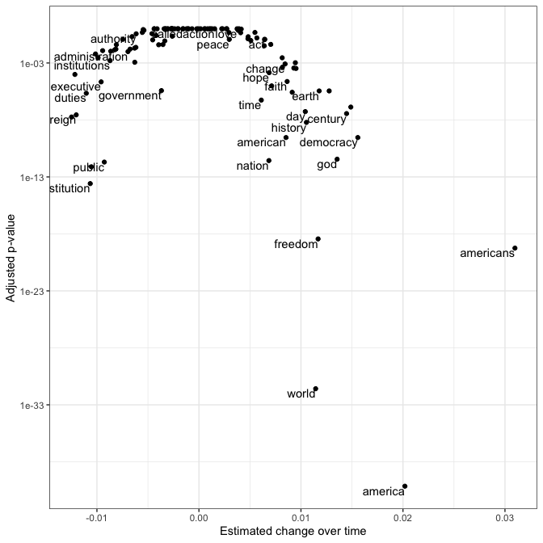

```r
library(ggplot2)

models %>%
  mutate(adjusted.p.value = p.adjust(p.value)) %>%
  ggplot(aes(estimate, adjusted.p.value)) +
  geom_point() +
  scale_y_log10() +
  geom_text(aes(label = word), vjust = 1, hjust = 1,
            check_overlap = TRUE) +
  xlab("Estimated change over time") +
  ylab("Adjusted p-value")
```

We can also use the ggplot2 package to display the top 6 terms that have changed in frequency over time.

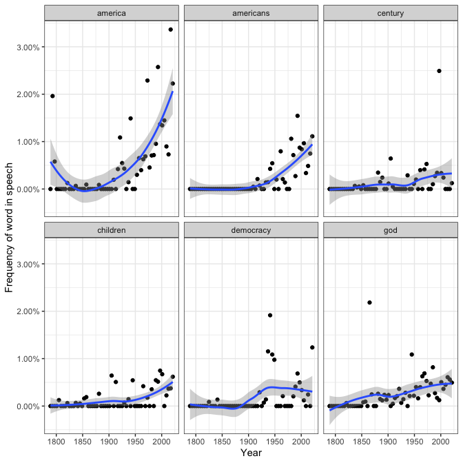

```r
library(scales)

models %>%
  top_n(6, abs(estimate)) %>%
  inner_join(inaug_freq) %>%
  ggplot(aes(Year, percent)) +
  geom_point() +
  geom_smooth() +
  facet_wrap(~ word) +
  scale_y_continuous(labels = percent_format()) +
  ylab("Frequency of word in speech")
```